# Научная презентация по лабораторной работе №8

Дисциплина:Операционные системы

Абрамова У. М.

Российский университет дружбы народов, Москва, Россия

Математический институт имени Никольского, Москва, Россия

05.04.2025

# Информация

## Докладчик

- Абрамова Ульяна Михайловна
- Студент НММбд-01-24
- Российский университет дружбы народов
- 1132246782@pfur.ru
- https://github.com/Ulyana-abr

# Вводная часть

## Актуальность

- Работа с файловой системой Linux актуальна, так как эта операционная система широко используется, в том числе среди разработчиков.

## Цели и задачи

- Ознакомление с инструментами поиска файлов и фильтрации текстовых данных.
- Приобретение практических навыков: по управлению процессами, по проверке использования диска и обслуживанию файловых систем.

## Материалы и методы

- linux

## Содержание исследования

записываю в файл file.txt названия файлов, содержащихся в каталоге /etc, и дописываю в этот же файл названия файлов, содержащихся в нашем домашнем каталоге (рис. 1).

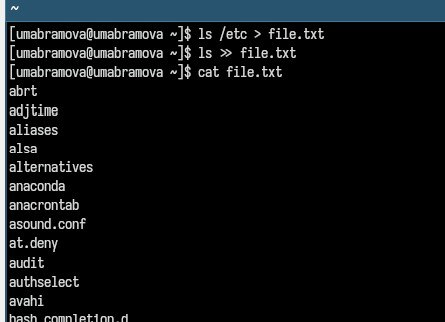

вывод и дописывание файлов

## Содержание исследования

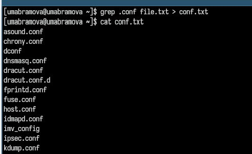

вывод и записывание в новый текстовый файл

## Содержание исследования

С помощью команды find определяю, какие файлы в нашем домашнем каталоге имеют имена, начинавшиеся с символа c (рис. 3).

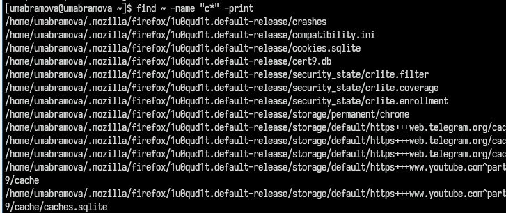

вывод файлов с одинаковым первым символом

## Содержание исследования

Вывожу на экран постранично имена файлов из каталога /etc, начинающиеся с символа h, также использую команду find (рис. 4)

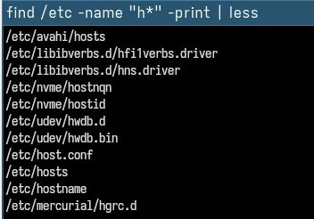

постраничный вывод файлов

## Содержание исследования

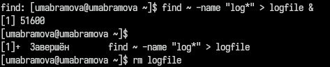

Запуск в фоновом режиме процесса

## Содержание исследования

Запускаю в фоновом режиме редактор gedit, Определили идентификатор процесса gedit, используя команду ps, конвейер и фильтр grep. Справка команды kill была получена и прочитана в предыдущей лабораторной работе, поэтому использую её для завершения процесса gedit. (рис. 6)

## Содержание исследования

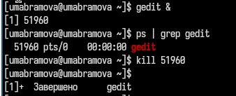

gedit в фоновом режиме

## Содержание исследования

С помощью команды man получаю дополнительную информацию о командах df и du (рис. 7, 8)

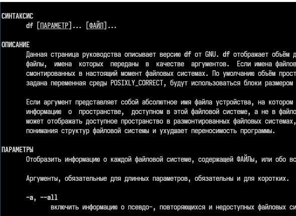

использование команды man

## Содержание исследования

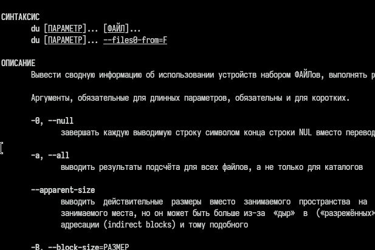

использование команды man

## Содержание исследования

После чего выполняю данные команды (рис. 9, 10)

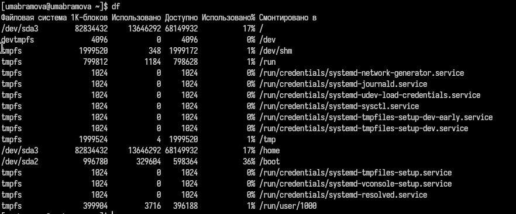

выполнение df

## Содержание исследования

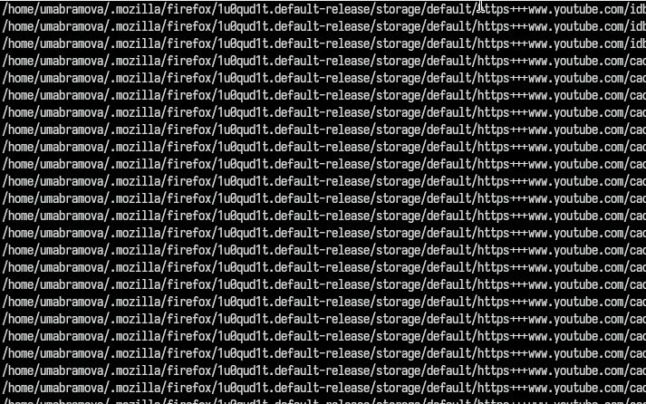

## Содержание исследования

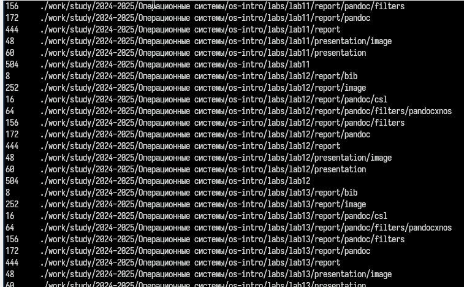

## Результаты

- В данной работе я ознакомилась с инструментами поиска файлов и фильтрации текстовых данных. А также приобрела практические навыки по управлению процессами.

## Итоговый слайд

- Чем больше вы практикуетесь и пробуете новое, тем больше и чаще вы будете получать знаний и опыта в разных сферах.